# Bayesian linear regression

Quan Gan

2/19/2022

## Load data in

There are three data sets with low, intermediate, and high errors.

```r
data_low <- read_csv("../Data/Dataset_S1_Mar8.csv")
data_intermediate <- read_csv("../Data/Dataset_S2_Mar8.csv")
data_high <- read_csv("../Data/Dataset_S3_Mar8.csv")
```

## Bayesian linear regression

Using the Bayesian linear regression without error The model setup is is stan/Bayesian_linear_model.stan

```r
model_without_error <- function(data, iter, chains, seed){
  rstan_options(auto_write = TRUE)
  mark <- sample(                                     # Mark for train-test
    c(rep(0, 0.7*nrow(data)),
    c(rep(1, 0.3*nrow(data)))))
  train <- data[mark == 0,]                              # train data
  test <- data[mark == 1,]                               # test data

  stan_date <- list(N = nrow(train), Temperature = train$Temperature, D47 = train$D47)
  model <- stan(file = "stan/Bayesian_linear_model.stan", data = stan_date, iter = iter, chains = chains, seed = seed)
  result <- rstan::extract(model)

  train_MSE <- mean((train$D47 - (train$Temperature * summary(result$beta)[3] + summary(result$alpha)[3]))^2)    # Train set MSE
  test_MSE <- mean((test$D47 - (test$Temperature * summary(result$beta)[3] + summary(result$alpha)[3]))^2)# Test set MSE

  Intercept_names <- c("Median Intercept", "Intercept Std. Error", "2.5%", "92.5%")
  Intercept_values <- c(summary(result$alpha)[3], summary(model)$summary[1, 2], summary(result$alpha)[2],summary(result$alpha)[5])
  names(Intercept_values) <- Intercept_names

  Slope_names <- c("Median Slope", "Slope Std. Error", "2.5%", "92.5%")
  Slope_values <- c(summary(result$beta)[3], summary(model)$summary[2, 2], summary(result$beta)[2],summary(result$beta)[5])
  names(Slope_values) <- Slope_names

  MSE_names <- c("Median Train MSE", "Median Test MSE")
  MSE_values <- c(train_MSE, test_MSE)
  names(MSE_values) <- MSE_names

  return(c(Intercept_values, Slope_values, MSE_values))
}

# create data visualization
createPlot <- function(data, result, title, caption) {
  plot_object <- data %>%
    ggplot(aes(x = x_TRUE, y=y_TRUE)) +
    geom_ribbon(aes(ymin = result[7] * x_TRUE + result[4] , ymax = result[8] * x_TRUE + result[3]), fill = "orange") +
    geom_point() +
    geom_abline(slope = 0.0369, intercept = 0.268, color = 'red') +
    geom_abline(slope = result[5], intercept = result[1], color = 'yellow') +
    labs(title = title,
         caption = paste(caption, "\n", greeks("alpha"), "=",round(result[1], 4), "(95% CI", round(result[3], 4),"-", round(result[4],4), ")\n"
         , greeks("beta"), "=",round(result[5], 4), "(95% CI", round(result[7], 4),"-", round(result[8],4), ")" ))+
    xlab(expression(paste("True Temperature in ", ""^"o", "K"))) +
    ylab(expression(paste("True D47 (", ""^"o", "/"["oo"], ")")))
  return(plot_object)
}
```

### Data with low error

```r
results_low <- model_without_error(data_low, 1000, 4, 1234)
rbind(results_low) %>% kable()
```

|  | Median Intercept | Intercept Std. Error | 2.5% | 92.5% | Median Slope | Slope Std. Error | 2.5% | 92.5% | Median Train MSE | Median Test MSE |
| --- | --- | --- | --- | --- | --- | --- | --- | --- | --- | --- |
| results_low | 0.2621852 | 0.0001435 | 0.2605663 | 0.263936 | 0.0373071 | 1.14e-05 | 0.0371739 | 0.0374394 | 0.0001537 | 0.0001739 |

#### Comparing result to the true parameters

Plot confident interval area of the median slope/intercept of bootstrapping results And comparing it to the true slope/intercept

I use the true data points to plot.

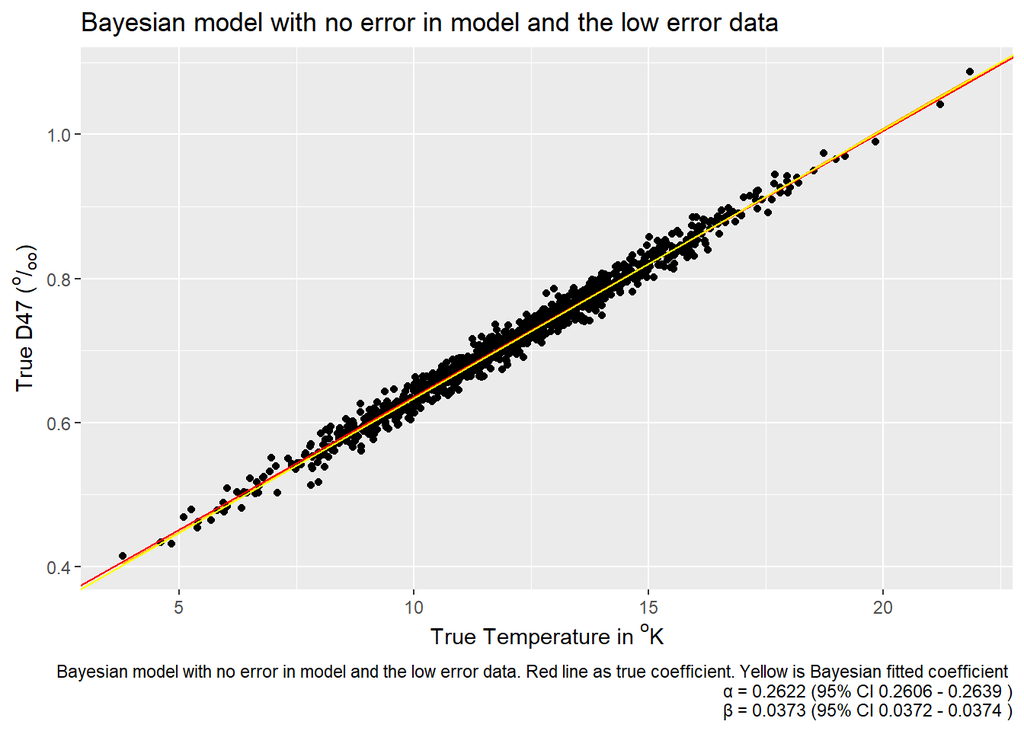

```r
createPlot(data_low,
           results_low,
           "Bayesian model with no error in model and the low error data",
           "Bayesian model with no error in model and the low error data. Red line as true coefficient. Yellow is Bayesian fitted coefficient")
```

### Data with intermediate error

```r
results_intermediate <- model_without_error(data_intermediate, 1000, 4, 1234)
rbind(results_intermediate) %>% kable()
```

|  | Median Intercept | Intercept Std. Error | 2.5% | 92.5% | Median Slope | Slope Std. Error | 2.5% | 92.5% | Median Train MSE | Median Test MSE |
| --- | --- | --- | --- | --- | --- | --- | --- | --- | --- | --- |
| results_intermediate | 0.2633953 | 0.0002256 | 0.2610058 | 0.2665264 | 0.0372017 | 1.8e-05 | 0.0369624 | 0.0374038 | 0.0005657 | 0.0006262 |

#### Comparing result to the true parameters

Plot confident interval area of the median slope/intercept of bootstrapping results And comparing it to the true slope/intercept

I use the true data points to plot.

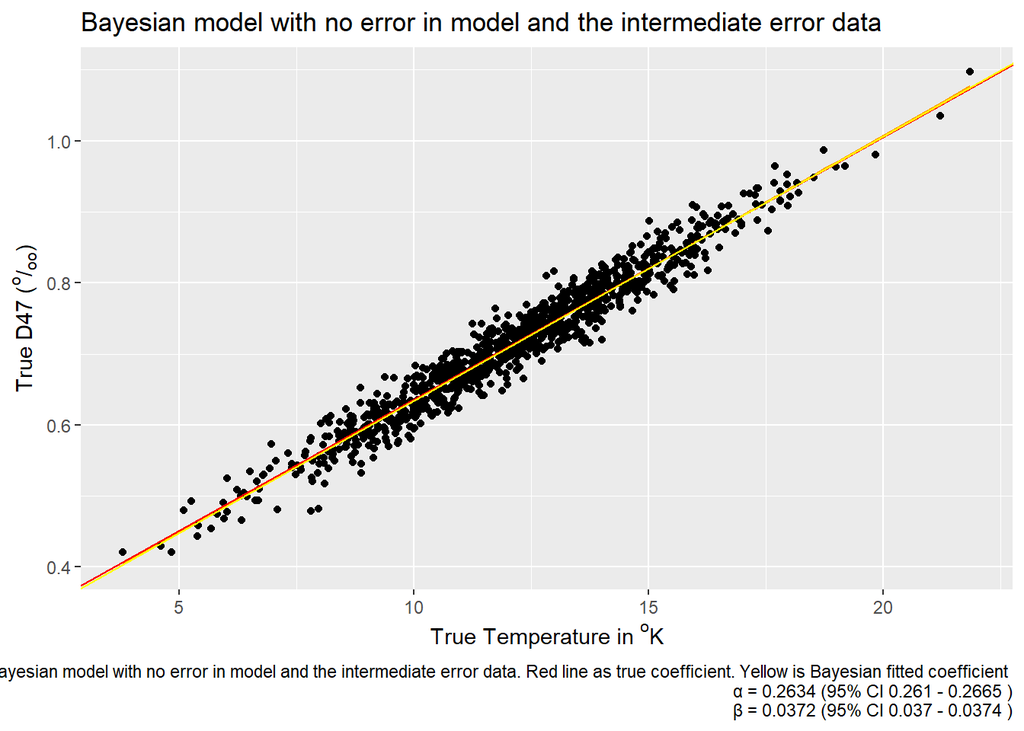

```r
createPlot(data_intermediate,
           results_intermediate,
           "Bayesian model with no error in model and the intermediate error data",
           "Bayesian model with no error in model and the intermediate error data. Red line as true coefficient. Yellow is Bayesian fitted coefficient")
```

### Data with high error

```r
results_high <- model_without_error(data_high, 1000, 4, 1234)
rbind(results_high) %>% kable()
```

|  | Median Intercept | Intercept Std. Error | 2.5% | 92.5% | Median Slope | Slope Std. Error | 2.5% | 92.5% | Median Train MSE | Median Test MSE |
| --- | --- | --- | --- | --- | --- | --- | --- | --- | --- | --- |
| results_high | 0.2655137 | 0.0002823 | 0.2622128 | 0.2685777 | 0.0370577 | 2.24e-05 | 0.0368037 | 0.0373153 | 0.0009242 | 0.0008691 |

#### Comparing result to the true parameters

Plot confident interval area of the median slope/intercept of bootstrapping results And comparing it to the true slope/intercept

I use the true data points to plot.

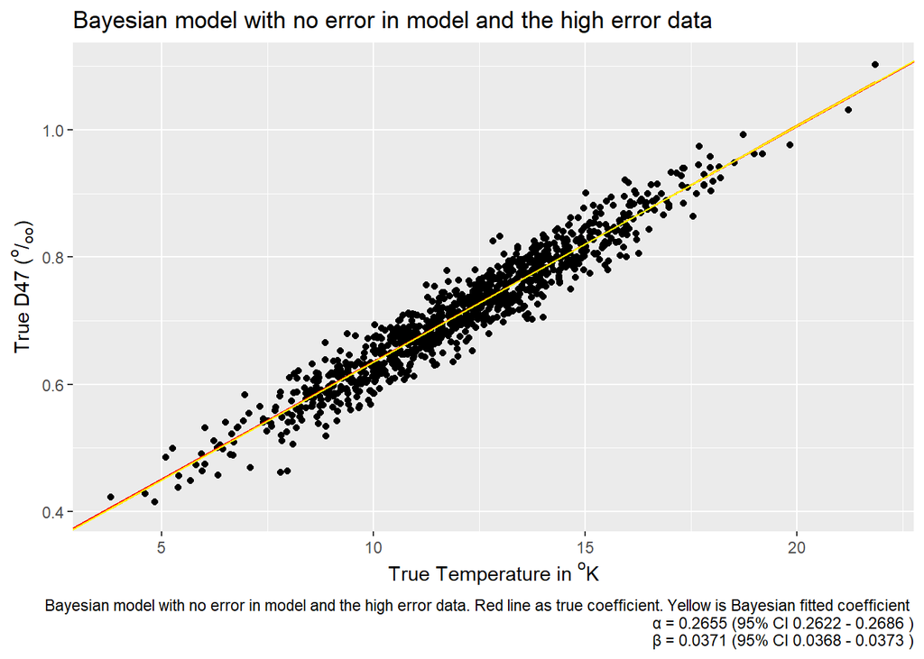

```r
createPlot(data_high,
           results_high,
           "Bayesian model with no error in model and the high error data",
           "Bayesian model with no error in model and the high error data. Red line as true coefficient. Yellow is Bayesian fitted coefficient")
```

## Bayesian linear regression Results summary

```r
rbind(results_low, results_intermediate, results_high) %>% kable()
```

|  | Median Intercept | Intercept Std. Error | 2.5% | 92.5% | Median Slope | Slope Std. Error | 2.5% | 92.5% | Median Train MSE | Median Test MSE |
| --- | --- | --- | --- | --- | --- | --- | --- | --- | --- | --- |
| results_low | 0.2621852 | 0.0001435 | 0.2605663 | 0.2639360 | 0.0373071 | 1.14e-05 | 0.0371739 | 0.0374394 | 0.0001537 | 0.0001739 |
| results_intermediate | 0.2633953 | 0.0002256 | 0.2610058 | 0.2665264 | 0.0372017 | 1.80e-05 | 0.0369624 | 0.0374038 | 0.0005657 | 0.0006262 |
| results_high | 0.2655137 | 0.0002823 | 0.2622128 | 0.2685777 | 0.0370577 | 2.24e-05 | 0.0368037 | 0.0373153 | 0.0009242 | 0.0008691 |

## Bayesian Linear Regression with Errors

Using the Bayesian linear regression with error The model setup is is stan/Bayesian_linear_model_with_error.stan

```r
model_with_error <- function(data, iter, chains, seed){
  rstan_options(auto_write = TRUE)

  mark <- sample(                                     # Mark for train-test
    c(rep(0, 0.7*nrow(data)),
    c(rep(1, 0.3*nrow(data)))))
  train <- data[mark == 0,]                              # train data
  test <- data[mark == 1,]                               # test data
  stan_date <- list(N = nrow(train),
                      Temperature = train$Temperature,
                      Temperature_true = train$x_TRUE,
                      Temperature_error = abs(train$TempError),
                      D47 = train$D47,
                      D47_true = train$y_TRUE,
                      D47_error = abs(train$D47error))

  model <- stan(file = "stan/Bayesian_linear_model_with_error.stan", data = stan_date, iter = iter, chains = chains, seed = seed)

  result <- rstan::extract(model)

  train_MSE <- mean((train$D47 - (train$Temperature * summary(result$beta)[3] + summary(result$alpha)[3]))^2)    # Train set MSE
  test_MSE <- mean((test$D47 - (test$Temperature * summary(result$beta)[3] + summary(result$alpha)[3]))^2)# Test set MSE

  Intercept_names <- c("Median Intercept", "Intercept Std. Error", "2.5%", "92.5%")
  Intercept_values <- c(summary(result$alpha)[3], summary(model)$summary[1, 2], summary(result$alpha)[2],summary(result$alpha)[5])
  names(Intercept_values) <- Intercept_names

  Slope_names <- c("Median Slope", "Slope Std. Error", "2.5%", "92.5%")
  Slope_values <- c(summary(result$beta)[3], summary(model)$summary[2, 2], summary(result$beta)[2],summary(result$beta)[5])
  names(Slope_values) <- Slope_names

  MSE_names <- c("Median Train MSE", "Median Test MSE")
  MSE_values <- c(train_MSE, test_MSE)
  names(MSE_values) <- MSE_names

  return(c(Intercept_values, Slope_values, MSE_values))
}
```

### Data with low error

```r
results_low <- model_with_error(data_low, 1000, 4, 1234)
rbind(results_low) %>% kable()
```

|  | Median Intercept | Intercept Std. Error | 2.5% | 92.5% | Median Slope | Slope Std. Error | 2.5% | 92.5% | Median Train MSE | Median Test MSE |
| --- | --- | --- | --- | --- | --- | --- | --- | --- | --- | --- |
| results_low | 0.264365 | 0.0001351 | 0.2628707 | 0.2659012 | 0.0371613 | 1.07e-05 | 0.0370415 | 0.0372833 | 0.0001625 | 0.0001527 |

#### Comparing result to the true parameters

Plot confident interval area of the median slope/intercept of bootstrapping results And comparing it to the true slope/intercept

I use the true data points to plot.

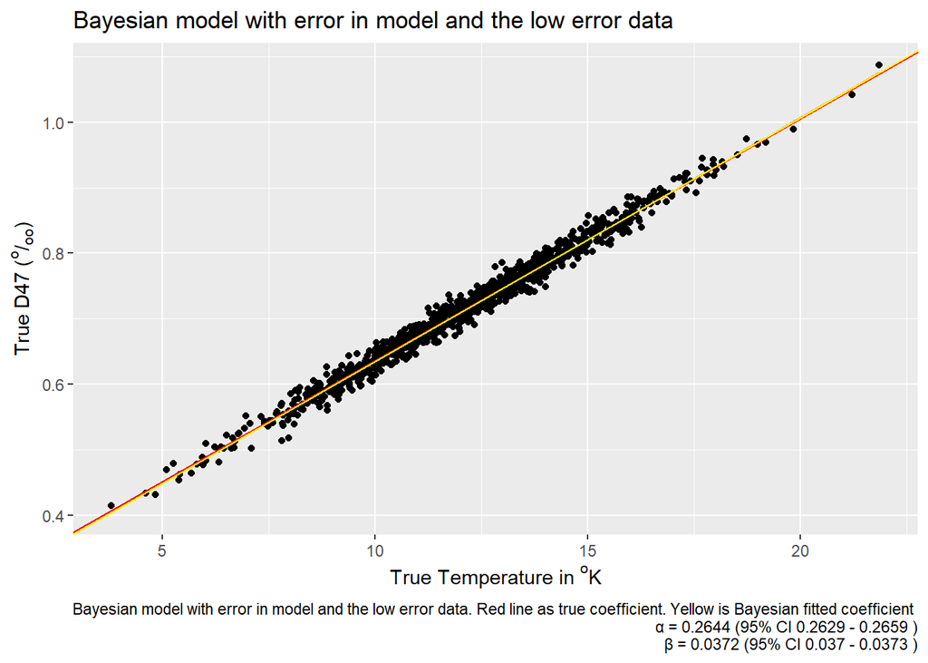

```r
createPlot(data_low,
           results_low,
           "Bayesian model with error in model and the low error data",
           "Bayesian model with error in model and the low error data. Red line as true coefficient. Yellow is Bayesian fitted coefficient")
```

### Data with Intermediate error

```r
results_intermediate <- model_with_error(data_intermediate, 1000, 4, 1234)
rbind(results_intermediate) %>% kable()
```

|  | Median Intercept | Intercept Std. Error | 2.5% | 92.5% | Median Slope | Slope Std. Error | 2.5% | 92.5% | Median Train MSE | Median Test MSE |
| --- | --- | --- | --- | --- | --- | --- | --- | --- | --- | --- |
| results_intermediate | 0.2595108 | 0.0002295 | 0.2564837 | 0.2626264 | 0.0374375 | 1.8e-05 | 0.037189 | 0.0376681 | 0.0005671 | 0.0006268 |

#### Comparing result to the true parameters

Plot confident interval area of the median slope/intercept of bootstrapping results And comparing it to the true slope/intercept

I use the true data points to plot.

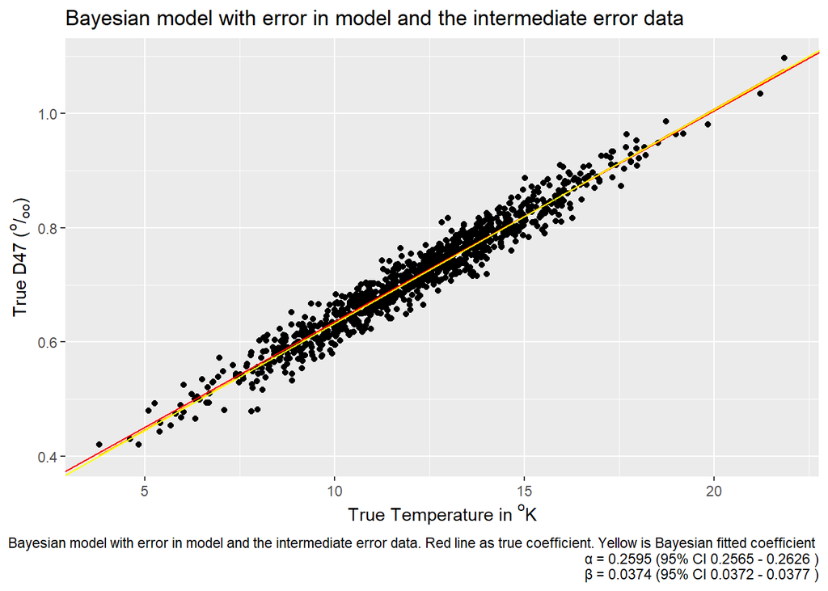

```r
createPlot(data_intermediate,
           results_intermediate,
           "Bayesian model with error in model and the intermediate error data",
           "Bayesian model with error in model and the intermediate error data. Red line as true coefficient. Yellow is Bayesian fitted coefficient")
```

### Data with High error

```r
results_high <- model_with_error(data_high, 1000, 4, 1234)
rbind(results_high) %>% kable()
```

|  | Median Intercept | Intercept Std. Error | 2.5% | 92.5% | Median Slope | Slope Std. Error | 2.5% | 92.5% | Median Train MSE | Median Test MSE |
| --- | --- | --- | --- | --- | --- | --- | --- | --- | --- | --- |
| results_high | 0.2599226 | 0.0002732 | 0.2569892 | 0.2628888 | 0.0375336 | 2.18e-05 | 0.0373013 | 0.037771 | 0.0008231 | 0.0011013 |

#### Comparing result to the true parameters

Plot confident interval area of the median slope/intercept of bootstrapping results And comparing it to the true slope/intercept

I use the true data points to plot.

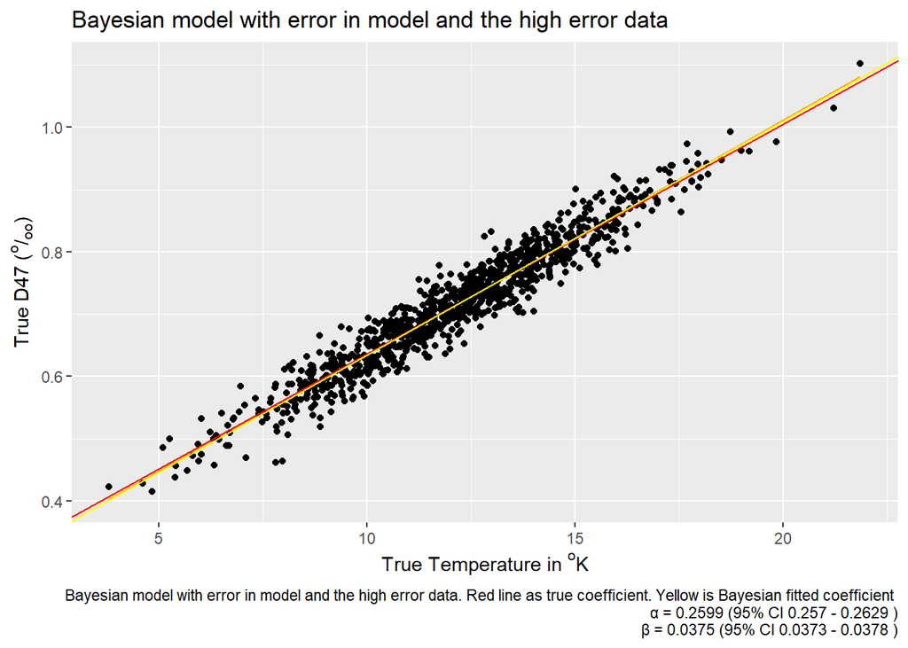

```r
createPlot(data_high,
           results_high,
           "Bayesian model with error in model and the high error data",
           "Bayesian model with error in model and the high error data. Red line as true coefficient. Yellow is Bayesian fitted coefficient")
```

## Bayesian linear regression Results summary

```r
rbind(results_low, results_intermediate, results_high) %>% kable()
```

|  | Median Intercept | Intercept Std. Error | 2.5% | 92.5% | Median Slope | Slope Std. Error | 2.5% | 92.5% | Median Train MSE | Median Test MSE |
| --- | --- | --- | --- | --- | --- | --- | --- | --- | --- | --- |
| results_low | 0.2643650 | 0.0001351 | 0.2628707 | 0.2659012 | 0.0371613 | 1.07e-05 | 0.0370415 | 0.0372833 | 0.0001625 | 0.0001527 |
| results_intermediate | 0.2595108 | 0.0002295 | 0.2564837 | 0.2626264 | 0.0374375 | 1.80e-05 | 0.0371890 | 0.0376681 | 0.0005671 | 0.0006268 |
| results_high | 0.2599226 | 0.0002732 | 0.2569892 | 0.2628888 | 0.0375336 | 2.18e-05 | 0.0373013 | 0.0377710 | 0.0008231 | 0.0011013 |